# Exemple d’analyse

LATIF Mehdi

11/10/2016

## Description : Analyse des données sur la santé mentale en prison :

**URL** : http://rmarkdown.rstudio.com/authoring_basics.html

Défintion du workspace par défaut et chargement du dataframe

```r
setwd("~/XX_Université_fun/univfunR/TP/LAB3")
smp <- read.csv2("/comptes/E131729J/XX_Université_fun/univfunR/TP/smp2.csv")
```

###### TADAH

**Note :** Si l’on considère que ce n’est pas important à affichier, il suffit d’écrire dans le chunk echo = FALSE

###### Et rien apparait RETADAH

Affichage des variables contenues dans le DATAFRAMES SMP

```r
names(smp)
```

```
##  [1] "age"          "prof"         "duree"        "discip"
##  [5] "n.enfant"     "n.fratrie"    "ecole"        "separation"
##  [9] "juge.enfant"  "place"        "abus"         "grav.cons"
## [13] "dep.cons"     "ago.cons"     "ptsd.cons"    "alc.cons"
## [17] "subst.cons"   "scz.cons"     "char"         "rs"
## [21] "ed"           "dr"           "suicide.s"    "suicide.hr"
## [25] "suicide.past" "dur.interv"
```

Résumé synthétique des différentes variables contenues dans le fichier SMP

```r
str(smp)
```

```
## 'data.frame':    799 obs. of  26 variables:
##  $ age         : int  31 49 50 47 23 34 24 52 42 45 ...
##  $ prof        : Factor w/ 8 levels "agriculteur",..: 3 NA 7 6 8 6 3 2 6 6 ...
##  $ duree       : int  4 NA 5 NA 4 NA NA 5 4 NA ...
##  $ discip      : int  0 0 0 0 1 0 0 0 1 0 ...
##  $ n.enfant    : int  2 7 2 0 1 3 5 2 1 2 ...
##  $ n.fratrie   : int  4 3 2 6 6 2 3 9 12 5 ...
##  $ ecole       : int  1 2 2 1 1 2 1 2 1 2 ...
##  $ separation  : int  0 1 0 1 1 0 1 0 1 0 ...
##  $ juge.enfant : int  0 0 0 0 NA 0 1 0 1 0 ...
##  $ place       : int  0 0 0 1 1 0 1 0 0 0 ...
##  $ abus        : int  0 0 0 0 0 0 0 0 1 1 ...
##  $ grav.cons   : int  1 2 2 1 2 1 5 1 5 5 ...
##  $ dep.cons    : int  0 0 0 0 1 0 1 0 1 0 ...
##  $ ago.cons    : int  1 0 0 0 0 0 0 0 0 0 ...
##  $ ptsd.cons   : int  0 0 0 0 0 0 0 0 0 0 ...
##  $ alc.cons    : int  0 0 0 0 0 0 0 0 1 1 ...
##  $ subst.cons  : int  0 0 0 0 0 0 1 0 1 0 ...
##  $ scz.cons    : int  0 0 0 0 0 0 0 0 0 0 ...
##  $ char        : int  1 1 1 1 1 1 1 1 4 1 ...
##  $ rs          : int  2 2 2 2 2 1 3 2 3 2 ...
##  $ ed          : int  1 2 3 2 2 2 3 2 3 2 ...
##  $ dr          : int  1 1 2 2 2 1 2 2 1 2 ...
##  $ suicide.s   : int  0 0 0 1 0 0 3 0 4 0 ...
##  $ suicide.hr  : int  0 0 0 0 0 0 1 0 1 0 ...
##  $ suicide.past: int  0 0 0 0 1 0 1 0 1 0 ...
##  $ dur.interv  : int  NA 70 NA 105 NA NA 105 84 78 60 ...
```

Affichage des principaux paramètres statistiques des différentes variables contenues dans le fichier SMP variables contenues dans le fichier SMP

```r
summary(smp)
```

```
##       age                          prof         duree
##  Min.   :19.0   ouvrier              :227   Min.   :1.000
##  1st Qu.:28.0   sans emploi          :222   1st Qu.:4.000
##  Median :37.0   employ<e9>           :135   Median :5.000
##  Mean   :38.9   artisan              : 90   Mean   :4.302
##  3rd Qu.:48.0   prof.interm<e9>diaire: 58   3rd Qu.:5.000
##  Max.   :83.0   (Other)              : 61   Max.   :5.000
##  NA's   :2      NA's                 :  6   NA's   :223
##      discip         n.enfant        n.fratrie          ecole
##  Min.   :0.000   Min.   : 0.000   Min.   : 0.000   Min.   :1.000
##  1st Qu.:0.000   1st Qu.: 0.000   1st Qu.: 2.000   1st Qu.:1.000
##  Median :0.000   Median : 1.000   Median : 3.000   Median :2.000
##  Mean   :0.232   Mean   : 1.755   Mean   : 4.287   Mean   :1.866
##  3rd Qu.:0.000   3rd Qu.: 3.000   3rd Qu.: 6.000   3rd Qu.:2.000
##  Max.   :1.000   Max.   :13.000   Max.   :21.000   Max.   :5.000
##  NA's   :6       NA's   :26                        NA's   :5
##    separation      juge.enfant         place             abus
##  Min.   :0.0000   Min.   :0.0000   Min.   :0.0000   Min.   :0.0000
##  1st Qu.:0.0000   1st Qu.:0.0000   1st Qu.:0.0000   1st Qu.:0.0000
##  Median :0.0000   Median :0.0000   Median :0.0000   Median :0.0000
##  Mean   :0.4226   Mean   :0.2771   Mean   :0.2285   Mean   :0.2778
##  3rd Qu.:1.0000   3rd Qu.:1.0000   3rd Qu.:0.0000   3rd Qu.:1.0000
##  Max.   :1.0000   Max.   :1.0000   Max.   :1.0000   Max.   :1.0000
##  NA's   :11       NA's   :5        NA's   :7        NA's   :7
##    grav.cons        dep.cons         ago.cons        ptsd.cons
##  Min.   :1.000   Min.   :0.0000   Min.   :0.0000   Min.   :0.0000
##  1st Qu.:2.000   1st Qu.:0.0000   1st Qu.:0.0000   1st Qu.:0.0000
##  Median :4.000   Median :0.0000   Median :0.0000   Median :0.0000
##  Mean   :3.643   Mean   :0.3967   Mean   :0.1665   Mean   :0.2165
##  3rd Qu.:5.000   3rd Qu.:1.0000   3rd Qu.:0.0000   3rd Qu.:0.0000
##  Max.   :7.000   Max.   :1.0000   Max.   :1.0000   Max.   :1.0000
##  NA's   :4
##     alc.cons        subst.cons        scz.cons           char
##  Min.   :0.0000   Min.   :0.0000   Min.   :0.0000   Min.   :1.000
##  1st Qu.:0.0000   1st Qu.:0.0000   1st Qu.:0.0000   1st Qu.:1.000
##  Median :0.0000   Median :0.0000   Median :0.0000   Median :1.000
##  Mean   :0.1865   Mean   :0.2653   Mean   :0.0826   Mean   :1.512
##  3rd Qu.:0.0000   3rd Qu.:1.0000   3rd Qu.:0.0000   3rd Qu.:2.000
##  Max.   :1.0000   Max.   :1.0000   Max.   :1.0000   Max.   :4.000
##                                                     NA's   :96
##        rs              ed              dr          suicide.s
##  Min.   :1.000   Min.   :1.000   Min.   :1.000   Min.   :0.0000
##  1st Qu.:1.000   1st Qu.:1.000   1st Qu.:1.000   1st Qu.:0.0000
##  Median :2.000   Median :2.000   Median :2.000   Median :0.0000
##  Mean   :2.057   Mean   :1.866   Mean   :2.153   Mean   :0.7942
##  3rd Qu.:3.000   3rd Qu.:3.000   3rd Qu.:3.000   3rd Qu.:1.0000
##  Max.   :3.000   Max.   :3.000   Max.   :3.000   Max.   :5.0000
##  NA's   :103     NA's   :107     NA's   :111     NA's   :41
##    suicide.hr      suicide.past      dur.interv
##  Min.   :0.0000   Min.   :0.0000   Min.   :  0.00
##  1st Qu.:0.0000   1st Qu.:0.0000   1st Qu.: 48.00
##  Median :0.0000   Median :0.0000   Median : 60.00
##  Mean   :0.2013   Mean   :0.2841   Mean   : 61.89
##  3rd Qu.:0.0000   3rd Qu.:1.0000   3rd Qu.: 75.00
##  Max.   :1.0000   Max.   :1.0000   Max.   :120.00
##  NA's   :39       NA's   :14       NA's   :50
```

**Note :** Il est possible de faire un affichage unique de trois commandes dans un même *chunk* : pour cela, il faut ecrire : *{r, eval = c(1,3)}* (Dans notre cas, les lignes que l’on souhaites évaluer sont les lignes de commandes 1 et 3) :

```r
names(smp)
```

```
##  [1] "age"          "prof"         "duree"        "discip"
##  [5] "n.enfant"     "n.fratrie"    "ecole"        "separation"
##  [9] "juge.enfant"  "place"        "abus"         "grav.cons"
## [13] "dep.cons"     "ago.cons"     "ptsd.cons"    "alc.cons"
## [17] "subst.cons"   "scz.cons"     "char"         "rs"
## [21] "ed"           "dr"           "suicide.s"    "suicide.hr"
## [25] "suicide.past" "dur.interv"
```

```r
## str(smp)
summary(smp)
```

```
##       age                          prof         duree
##  Min.   :19.0   ouvrier              :227   Min.   :1.000
##  1st Qu.:28.0   sans emploi          :222   1st Qu.:4.000
##  Median :37.0   employ<e9>           :135   Median :5.000
##  Mean   :38.9   artisan              : 90   Mean   :4.302
##  3rd Qu.:48.0   prof.interm<e9>diaire: 58   3rd Qu.:5.000
##  Max.   :83.0   (Other)              : 61   Max.   :5.000
##  NA's   :2      NA's                 :  6   NA's   :223
##      discip         n.enfant        n.fratrie          ecole
##  Min.   :0.000   Min.   : 0.000   Min.   : 0.000   Min.   :1.000
##  1st Qu.:0.000   1st Qu.: 0.000   1st Qu.: 2.000   1st Qu.:1.000
##  Median :0.000   Median : 1.000   Median : 3.000   Median :2.000
##  Mean   :0.232   Mean   : 1.755   Mean   : 4.287   Mean   :1.866
##  3rd Qu.:0.000   3rd Qu.: 3.000   3rd Qu.: 6.000   3rd Qu.:2.000
##  Max.   :1.000   Max.   :13.000   Max.   :21.000   Max.   :5.000
##  NA's   :6       NA's   :26                        NA's   :5
##    separation      juge.enfant         place             abus
##  Min.   :0.0000   Min.   :0.0000   Min.   :0.0000   Min.   :0.0000
##  1st Qu.:0.0000   1st Qu.:0.0000   1st Qu.:0.0000   1st Qu.:0.0000
##  Median :0.0000   Median :0.0000   Median :0.0000   Median :0.0000
##  Mean   :0.4226   Mean   :0.2771   Mean   :0.2285   Mean   :0.2778
##  3rd Qu.:1.0000   3rd Qu.:1.0000   3rd Qu.:0.0000   3rd Qu.:1.0000
##  Max.   :1.0000   Max.   :1.0000   Max.   :1.0000   Max.   :1.0000
##  NA's   :11       NA's   :5        NA's   :7        NA's   :7
##    grav.cons        dep.cons         ago.cons        ptsd.cons
##  Min.   :1.000   Min.   :0.0000   Min.   :0.0000   Min.   :0.0000
##  1st Qu.:2.000   1st Qu.:0.0000   1st Qu.:0.0000   1st Qu.:0.0000
##  Median :4.000   Median :0.0000   Median :0.0000   Median :0.0000
##  Mean   :3.643   Mean   :0.3967   Mean   :0.1665   Mean   :0.2165
##  3rd Qu.:5.000   3rd Qu.:1.0000   3rd Qu.:0.0000   3rd Qu.:0.0000
##  Max.   :7.000   Max.   :1.0000   Max.   :1.0000   Max.   :1.0000
##  NA's   :4
##     alc.cons        subst.cons        scz.cons           char
##  Min.   :0.0000   Min.   :0.0000   Min.   :0.0000   Min.   :1.000
##  1st Qu.:0.0000   1st Qu.:0.0000   1st Qu.:0.0000   1st Qu.:1.000
##  Median :0.0000   Median :0.0000   Median :0.0000   Median :1.000
##  Mean   :0.1865   Mean   :0.2653   Mean   :0.0826   Mean   :1.512
##  3rd Qu.:0.0000   3rd Qu.:1.0000   3rd Qu.:0.0000   3rd Qu.:2.000
##  Max.   :1.0000   Max.   :1.0000   Max.   :1.0000   Max.   :4.000
##                                                     NA's   :96
##        rs              ed              dr          suicide.s
##  Min.   :1.000   Min.   :1.000   Min.   :1.000   Min.   :0.0000
##  1st Qu.:1.000   1st Qu.:1.000   1st Qu.:1.000   1st Qu.:0.0000
##  Median :2.000   Median :2.000   Median :2.000   Median :0.0000
##  Mean   :2.057   Mean   :1.866   Mean   :2.153   Mean   :0.7942
##  3rd Qu.:3.000   3rd Qu.:3.000   3rd Qu.:3.000   3rd Qu.:1.0000
##  Max.   :3.000   Max.   :3.000   Max.   :3.000   Max.   :5.0000
##  NA's   :103     NA's   :107     NA's   :111     NA's   :41
##    suicide.hr      suicide.past      dur.interv
##  Min.   :0.0000   Min.   :0.0000   Min.   :  0.00
##  1st Qu.:0.0000   1st Qu.:0.0000   1st Qu.: 48.00
##  Median :0.0000   Median :0.0000   Median : 60.00
##  Mean   :0.2013   Mean   :0.2841   Mean   : 61.89
##  3rd Qu.:0.0000   3rd Qu.:1.0000   3rd Qu.: 75.00
##  Max.   :1.0000   Max.   :1.0000   Max.   :120.00
##  NA's   :39       NA's   :14       NA's   :50
```

```r
gauss <- factor(smp$n.enfant)
table(gauss)
```

```
## gauss
##   0   1   2   3   4   5   6   7   8   9  10  11  13
## 214 220 125 101  55  31   7   7   7   2   2   1   1
```

```r
levels(gauss)[6:13]<-"5+"
table(gauss)
```

```
## gauss
##   0   1   2   3   4  5+
## 214 220 125 101  55  58
```

Affichage des pourcentage de chaque modalité de la variable :

```r
prop.table(table(gauss))
```

```
## gauss
##          0          1          2          3          4         5+
## 0.27684347 0.28460543 0.16170763 0.13065977 0.07115136 0.07503234
```

Modification des pourcentage (x100) pour avoir des résultats plus *lisibles* :

```r
f <- prop.table(table(gauss))*100
f
```

```
## gauss
##         0         1         2         3         4        5+
## 27.684347 28.460543 16.170763 13.065977  7.115136  7.503234
```

**Vérification :** La somme des fréquences cumulée est bien égale à 1 :

```r
r<-sum(f)/100
r
```

```
## [1] 1
```

**Représentation graphique** sous forme d’histogramme de la variable qualitative *gauss*

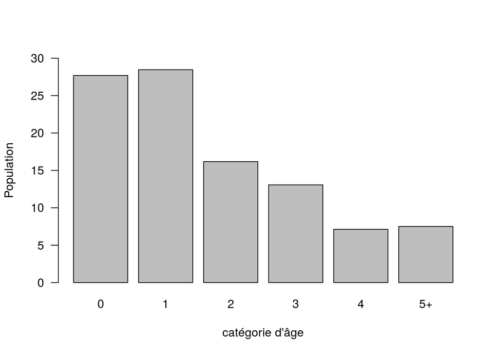

```r
barplot(f, ylim = c(0,30),las=1,xlab="catégorie d'âge", ylab="Population")
```